# Midterm Exam 1 Review Sheet

MAT143 Brief Calculus

**Scope**: All topics covered in Chapter 1.

- Graphical Search for Limits (including left and right limits)
  - **Example** (a). finding the left limit, right limit, and the existence of the limit of a function with the following given curve at $x = -2, 0, 3$, (b). Is the function continuous at $x = -2, 0, 3$?

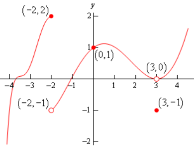

- Calculating limits (only focusing on the cases where limit exists at a point): **substitution method**. Please practice the examples shown in the flowchart.

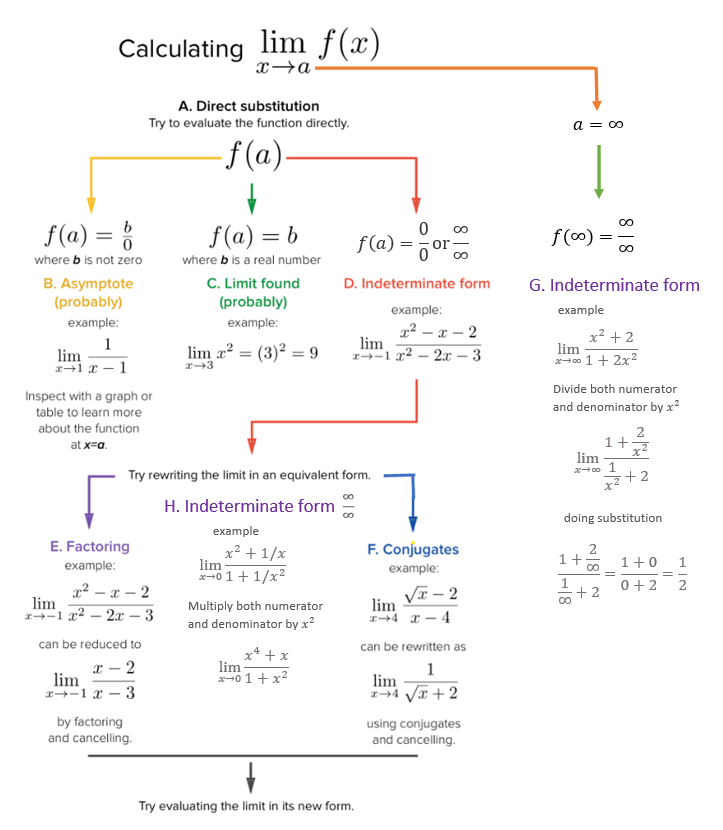

  - If the result is $b/0$, the limit is $\infty$.
  - If the result is $b$ and $|b| < \infty$, then you have the limit.
  - If the result is $0/0$ or $\infty / \infty$, you have an **indeterminate form**. You need to do some algebra to simplify the given function and then redo the substitution on the **simplified form** to get either $b/0$ or $|b| < \infty$.
- Average Rate of Change of A Function Over An Interval
  - Definition: $\frac{f(b)-f(a)}{b - a}$.
  - Difference Quotient: $\frac{f(x+h)-f(x)}{h}$.
    - Need to know how to find the **difference Quotient** for a given function. For example: find the difference quotient of $f(x) = x^2 + 1$.
- Derivative and Power Rule
  - Instantaneous Rate of Change (rate at a given $x = x_0$): $\lim_{x \to x_0}\frac{f(x +h)-f(x)}{h}$.
  - Definition notation of the derivative of $f(x)$: $f^\prime(x) = \lim_{x \to x_0}\frac{f(x +h)-f(x)}{h}$. $f^\prime(x)$ is also denoted by $\frac{d f(x)}{dx}$ or $\frac{d}{dx}f(x)$.
  - Power function and the power rule of the derivative $[x^a]^\prime = a x^{a -1}$.
- Basic Properties and Rules of Derivative
  - Constant function: $f(x) = C$, then $f^\prime(x) = (C)^\prime = 0$.
  - Identity function: $f(x) = x$, then $f^\prime(x) = (x)^\prime = 1$.
  - **Power Rule**: $f(x) = x^a$, then $f^\prime(x) = (x^a)^\prime = ax^{a-1}$.
- Basic Properties
  - Scalar multiplication: If $[bf(x)]^\prime = b[f(x)]^\prime$.
  - **Additive rule**: $[f(x) + g(x)]^\prime = f^\prime(x) + g^\prime(x)$

    **Example**: $[3\sqrt{x} + 5x^3]^\prime = [3\sqrt{x}]^\prime + [5x^3]^\prime = 3[x^{1/2}]^\prime + 5[x^3]^\prime = (3/2)x^{-1/2} + 15x^2$.
- Multiplicative, Quotient, and Chain Rule
  - **Multiplicative Rule**: $[f(x)g(x)]^\prime = f^\prime(x) g(x) + f(x)g^\prime(x)$.

    **Example**: $[(x+1)(x^2+1)]^\prime = (x+1)^\prime(x^2+1) + (x+1)(x^2+1)^\prime = (x^2+1)+(x+1)\times 2x = 3x^2+2x + 1.$
  - **Quotient Rule**: $[f(x)/g(x)]^\prime = [f^\prime(x) g(x) - f(x)g^\prime(x)]/[g(x)]^2$

    **Example**: $[x^2/(x+1)]^\prime = [(x^2)^\prime(x+1) - x^2(x+1)^\prime]/(x+1)^2 = [2x(x+1)-x^2]/(x+1)^2 = (x^2+2x)/(x+1)^2$.
  - **Chain Rule**: $[f\circ g(x)]^\prime = [f(g(x))]^\prime = f^\prime(g(x))\times g^\prime(x)$. The key is to identify $f(x)$ [the outer function] and $g(x)$[the inner function].

    **Example**: $[\sqrt[3]{(x^2+1)^5}]^\prime = [(x^2+1)^{5/3}]^\prime = \frac{5}{3}(x^2+1)\times (x^2+1)^\prime =\frac{5}{3}(x^2+1)\times (2x) =\frac{10x}{3}(x^2+1)$